# R Project: COVID-19 Modifying Crime Acitivty

12/10/2020

## Introduction

- Initial Questions
- Speculations
- Covid-19 Impact
- Sectors of Interest
- Research Parameters

## Initial hypothesis

- Q: Is there a factor which changes how DC crime occurs by the different types?
  - Hypothesis: Median income has the best effect in DC Crime
- Q: How does median age affect crime?
  - Hypothesis: Age and crime have a negative relationship
- Q: How does covid-19 affect crime rate?
  - Hypothesis: Covid-19 would increase crime due to a precedent of crime increases during disasters (Yale research)

## Initial hypothesis (continued)

- Q: Has covid-19 affected the time or the type of crime?
  - Hypothesis: The closer it gets to the evening, the higher the crime rate, and the fewer people commit crimes with weapons such as guns
- Q: How does crime vary by offense?
  - Hypothesis: People who committed violent crimes is lower than common crimes
- Q: How does crime vary by district?
  - Hypothesis: if we get closer to the center of DC, crime records increase

## Data Preparation

- Can not separate day from date
- Can not access 2020 census data
- Hard to pick the best appropriate chart to present data

## How does demographic effect DC crime?

- Potential factors
  - median age
  - median income
  - race
  - education attainment
  - poverty status

## Linear Regression Model

```
##
## Call:
## lm(formula = total_crime_num ~ ., data = lm_df)
##
## Coefficients:
##      (Intercept)      age_estimate   income_estimate     race_estimate
##        3.821e+02        -8.474e+00         5.881e-04        -1.265e-02
##     edu_estimate  poverty_estimate
##        1.766e-01        -6.363e-02
```

## How does age affect the crime

- the number of crimes facet by level of crime and shift of police fo each tract

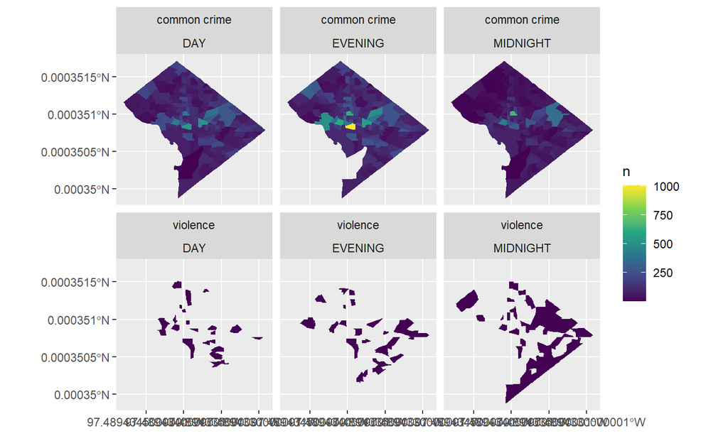

## DC average age for each tract

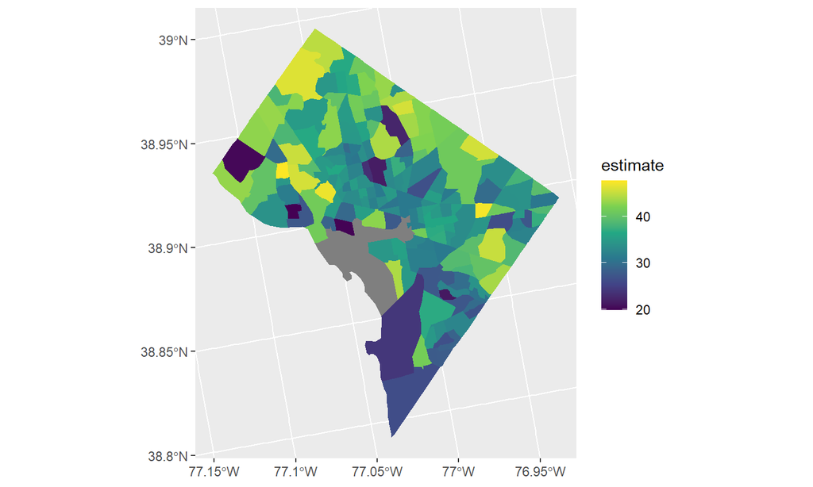

## How does covid-19 affect crime rate?

- How does covid-19 affect crime rate?

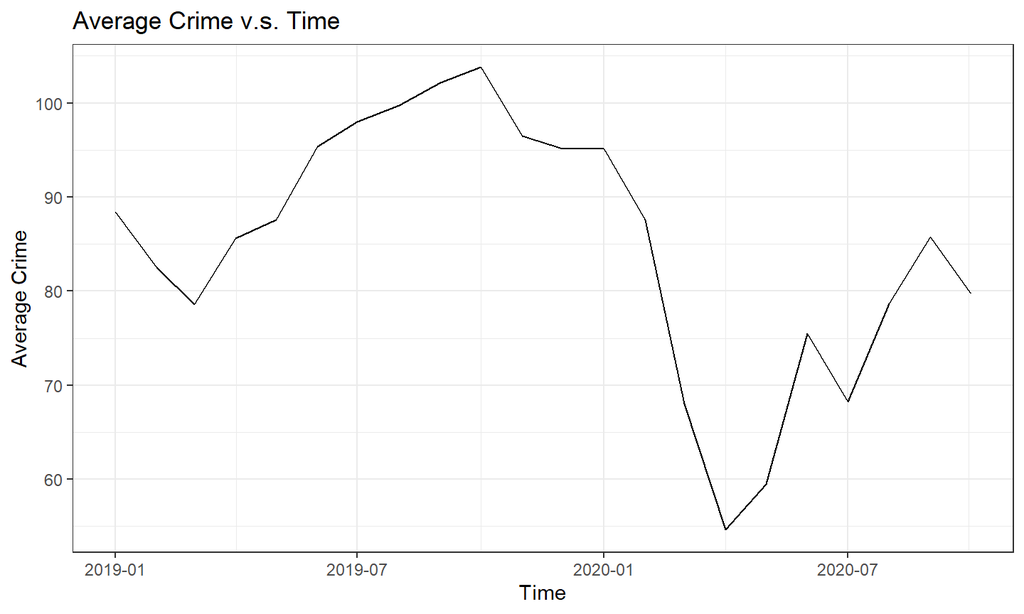

## Has covid-19 affected the time or the type of crime?

- Has covid-19 affected the time that people committed crime?

```
##
##            after_covid before_covid
##   DAY             0.35         0.34
##   EVENING         0.44         0.44
##   MIDNIGHT        0.21         0.22
```

## Has covid-19 affected the time or the type of crime?

- Has covid-19 affected by the time and level?

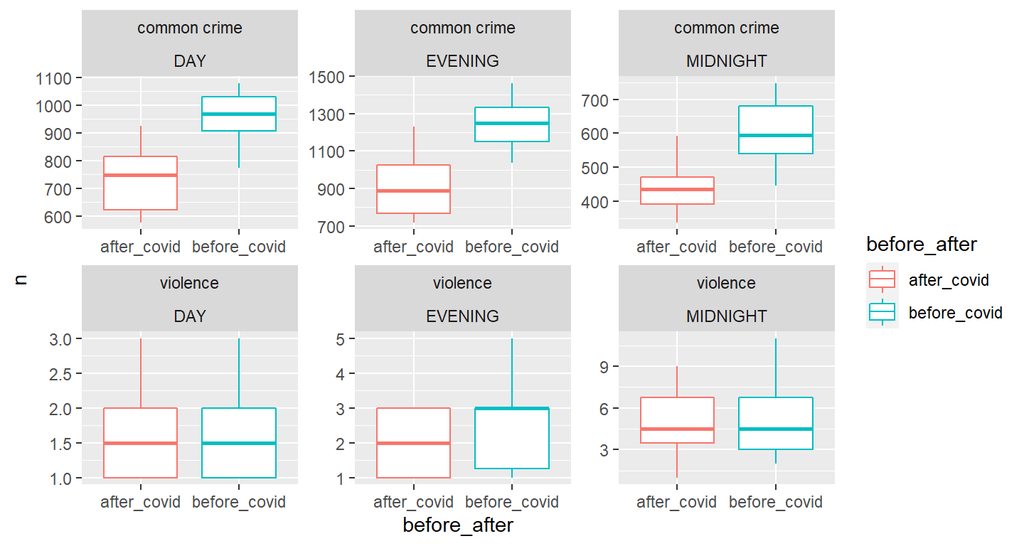

## Has covid-19 affected the time or the type of crime?

- Has covid-19 affected by the time and method?

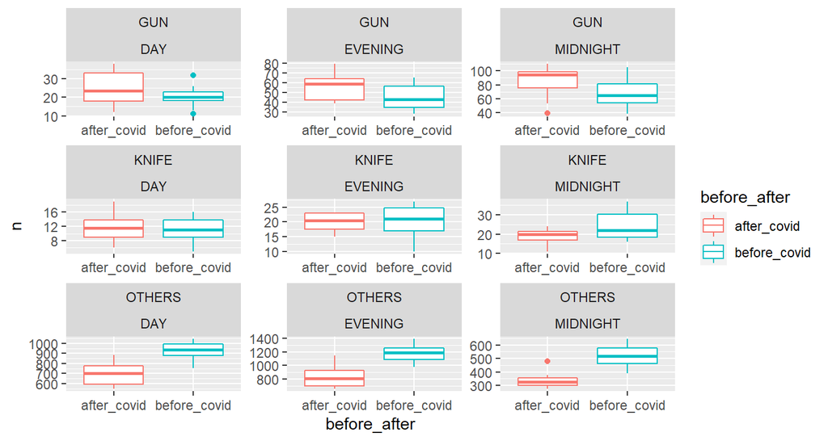

## How does crime vary by offense?

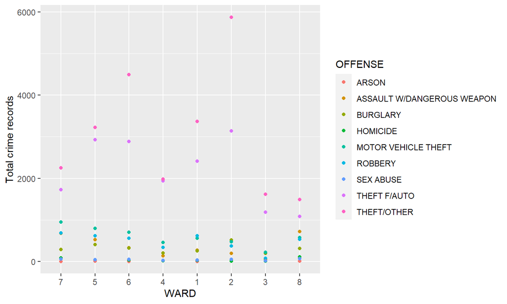

## How does crime vary by offense?

- key variables: ward,offense,total crime records(n)

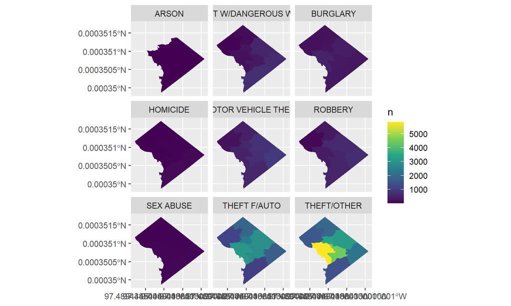

## level:common crime,violence

- Violence:HOMICIDE, SEX ABUSE, ASSAULT w/DANGEROUS WEAPON, ARSON
- Common crime:BURGLARY, MOTOR VEHICLE THEFT, ROBBERY, THEFT
- People who committed violent crimes is lower than common crimes

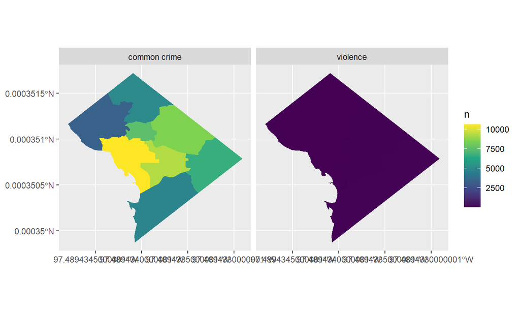

## How does crime vary by districts?

- Key variables: district, total crime records(n)
- Red dot represent American University

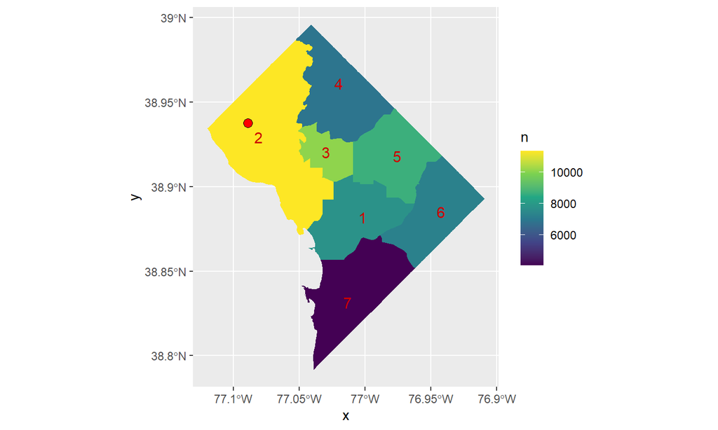

## Without THEFT

- District 2 become more safer

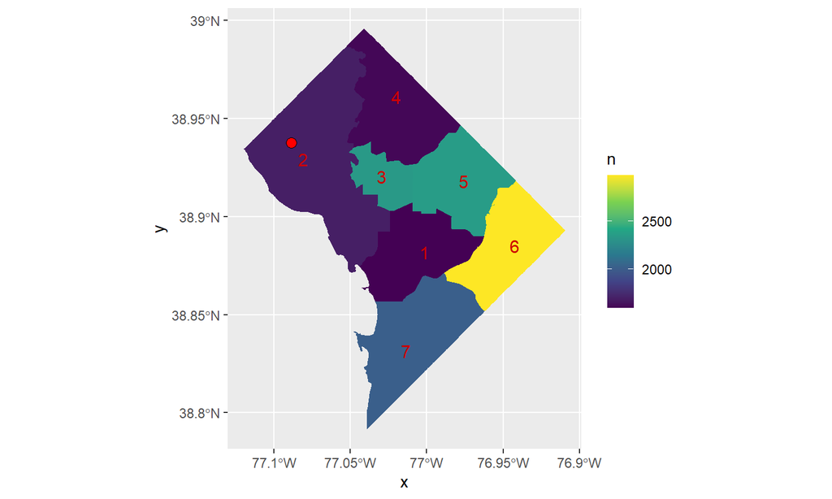

## References

- Tian, Ting, et al. “COVID-Net: A Deep Learning Based and Interpretable Predication Model for the County-Wise Trajectories of COVID-19 in the United States.” 2020, doi:10.1101/2020.05.26.20113787.